[figure not shown]

[figure not shown]

[figure not shown]

# Model fit

### Assumption checks

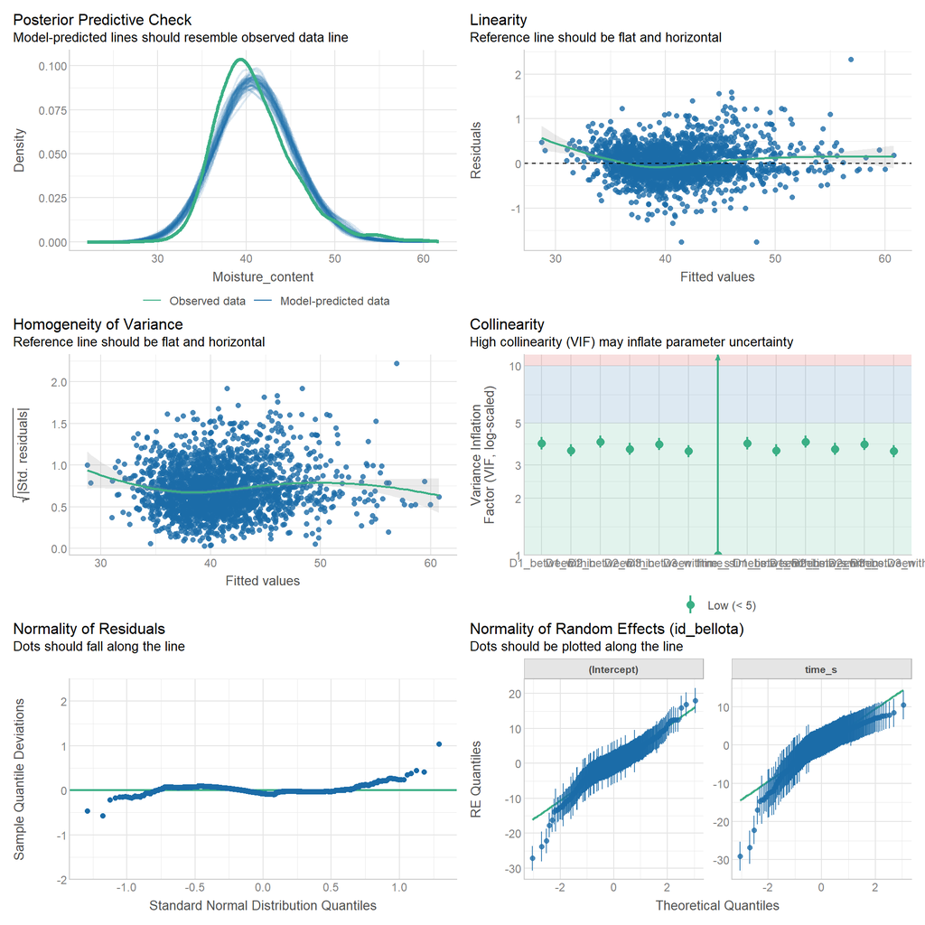

### Indices of model fit

| Metric | Value |
| --- | --- |
| AIC | 6055.7 |
| AICc | 6056.0 |
| BIC | 6157.1 |
| R2 (cond.) | 0.99 |
| R2 (marg.) | 0.41 |
| ICC | 0.98 |
| RMSE | 0.37 |
| Sigma | 0.47 |

For interpretation of performance metrics, please refer to [this documentation](https://easystats.github.io/performance/reference/model_performance.html).

# Parameter estimates

### Plot

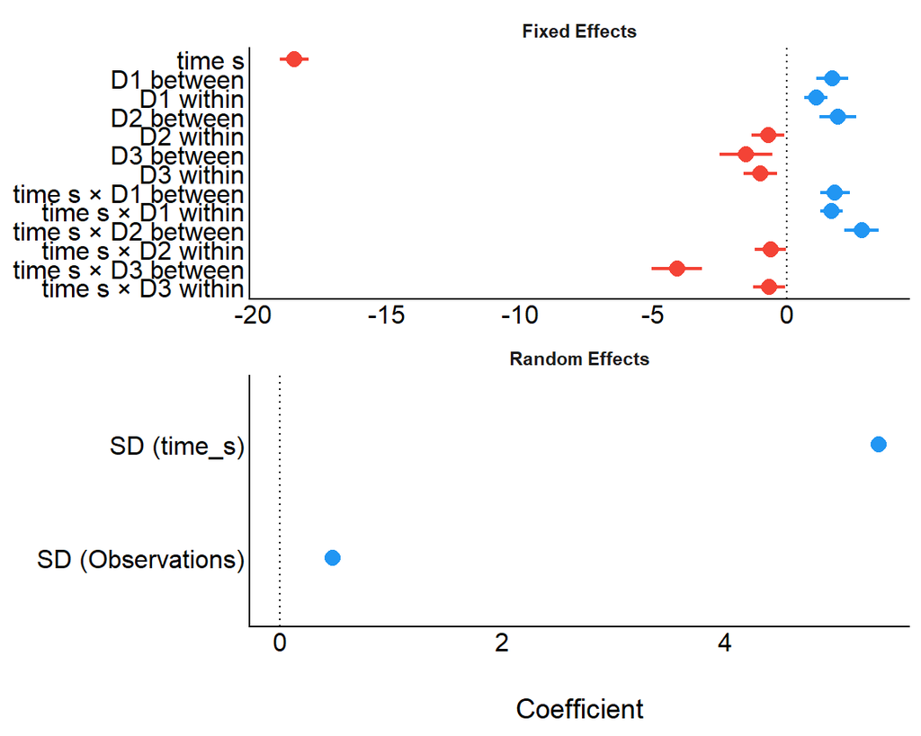

### Tabular summary

Fixed Effects

| Parameter | Coefficient | SE | 95% CI | z | p |
| --- | --- | --- | --- | --- | --- |
| (Intercept) | 24.12 | 0.29 | (23.55, 24.69) | 83.09 | < .001 |
| time s | -18.49 | 0.28 | (-19.03, -17.94) | -66.54 | < .001 |
| D1 between | 1.71 | 0.30 | (1.12, 2.31) | 5.64 | < .001 |
| D1 within | 1.11 | 0.22 | (0.68, 1.54) | 5.02 | < .001 |
| D2 between | 1.92 | 0.35 | (1.24, 2.60) | 5.54 | < .001 |
| D2 within | -0.70 | 0.31 | (-1.31, -0.09) | -2.24 | 0.025 |
| D3 between | -1.51 | 0.51 | (-2.50, -0.52) | -2.99 | 0.003 |
| D3 within | -0.98 | 0.32 | (-1.61, -0.35) | -3.05 | 0.002 |
| time s × D1 between | 1.82 | 0.29 | (1.25, 2.39) | 6.27 | < .001 |
| time s × D1 within | 1.69 | 0.21 | (1.27, 2.10) | 7.99 | < .001 |
| time s × D2 between | 2.82 | 0.33 | (2.17, 3.47) | 8.49 | < .001 |
| time s × D2 within | -0.60 | 0.30 | (-1.18, -0.02) | -2.01 | 0.044 |
| time s × D3 between | -4.12 | 0.48 | (-5.07, -3.17) | -8.52 | < .001 |
| time s × D3 within | -0.66 | 0.31 | (-1.26, -0.06) | -2.15 | 0.032 |

Random Effects

| Parameter | Coefficient |
| --- | --- |
| SD (Intercept: id_bellota) | 5.71 |
| SD (time_s: id_bellota) | 5.38 |
| Cor (Intercept~time_s: id_bellota) | 0.83 |
| SD (Residual) | 0.47 |

To find out more about table summary options, please refer to [this documentation](https://easystats.github.io/parameters/reference/model_parameters.html).

# Predicted Values

### Plot

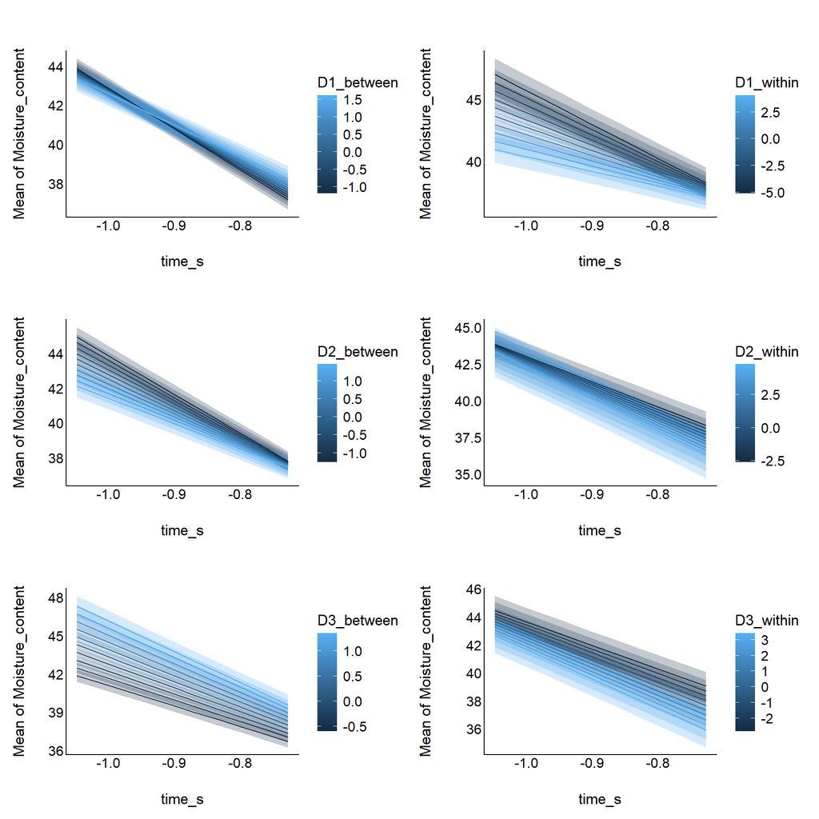

### Tabular summary

Estimated Marginal Means

| time_s | D1_between | Mean | SE | 95% CI | z |
| --- | --- | --- | --- | --- | --- |
| -1.05 | -1.19 | 43.89 | 0.26 | (43.37, 44.40) | 167.53 |
| -1.01 | -1.19 | 43.13 | 0.26 | (42.63, 43.64) | 167.27 |
| -0.98 | -1.19 | 42.38 | 0.25 | (41.88, 42.88) | 166.39 |
| -0.94 | -1.19 | 41.65 | 0.25 | (41.15, 42.14) | 164.89 |
| -0.90 | -1.19 | 40.89 | 0.25 | (40.40, 41.39) | 162.66 |
| -0.87 | -1.19 | 40.14 | 0.25 | (39.65, 40.63) | 159.76 |
| -0.83 | -1.19 | 39.41 | 0.25 | (38.92, 39.90) | 156.33 |
| -0.80 | -1.19 | 38.66 | 0.25 | (38.16, 39.16) | 152.21 |
| -0.76 | -1.19 | 37.90 | 0.26 | (37.40, 38.41) | 147.58 |
| -0.73 | -1.19 | 37.17 | 0.26 | (36.66, 37.68) | 142.67 |
| -1.05 | -0.88 | 43.82 | 0.22 | (43.39, 44.26) | 196.85 |
| -1.01 | -0.88 | 43.09 | 0.22 | (42.66, 43.52) | 196.65 |
| -0.98 | -0.88 | 42.36 | 0.22 | (41.94, 42.78) | 195.70 |
| -0.94 | -0.88 | 41.65 | 0.21 | (41.23, 42.07) | 194.02 |
| -0.90 | -0.88 | 40.92 | 0.21 | (40.50, 41.33) | 191.50 |
| -0.87 | -0.88 | 40.18 | 0.21 | (39.76, 40.60) | 188.18 |
| -0.83 | -0.88 | 39.47 | 0.21 | (39.05, 39.89) | 184.22 |
| -0.80 | -0.88 | 38.74 | 0.22 | (38.32, 39.16) | 179.46 |
| -0.76 | -0.88 | 38.01 | 0.22 | (37.58, 38.43) | 174.09 |
| -0.73 | -0.88 | 37.29 | 0.22 | (36.86, 37.73) | 168.39 |
| -1.05 | -0.57 | 43.76 | 0.19 | (43.39, 44.14) | 230.25 |
| -1.01 | -0.57 | 43.05 | 0.19 | (42.69, 43.42) | 230.12 |
| -0.98 | -0.57 | 42.34 | 0.18 | (41.98, 42.70) | 229.12 |
| -0.94 | -0.57 | 41.65 | 0.18 | (41.29, 42.01) | 227.26 |
| -0.90 | -0.57 | 40.94 | 0.18 | (40.58, 41.29) | 224.41 |
| -0.87 | -0.57 | 40.22 | 0.18 | (39.87, 40.58) | 220.63 |
| -0.83 | -0.57 | 39.53 | 0.18 | (39.17, 39.89) | 216.10 |
| -0.80 | -0.57 | 38.82 | 0.18 | (38.46, 39.18) | 210.62 |
| -0.76 | -0.57 | 38.11 | 0.19 | (37.74, 38.47) | 204.43 |
| -0.73 | -0.57 | 37.42 | 0.19 | (37.05, 37.79) | 197.84 |

[output cut: 70 more lines]

*Variable predicted: Moisture_content; Predictors modulated: time_s, D1_between; Predictors averaged: D1_within (0.00027), D2_between (-0.022), D2_within (0.001), D3_between (0.048), D3_within (-0.0008), id_bellota*

Estimated Marginal Means

| time_s | D1_within | Mean | SE | 95% CI | z |
| --- | --- | --- | --- | --- | --- |
| -1.05 | -5.11 | 47.02 | 0.65 | (45.74, 48.30) | 71.82 |
| -1.01 | -5.11 | 46.04 | 0.64 | (44.77, 47.30) | 71.43 |
| -0.98 | -5.11 | 45.05 | 0.64 | (43.80, 46.30) | 70.77 |
| -0.94 | -5.11 | 44.10 | 0.63 | (42.86, 45.33) | 69.85 |
| -0.90 | -5.11 | 43.11 | 0.63 | (41.88, 44.34) | 68.61 |
| -0.87 | -5.11 | 42.13 | 0.63 | (40.90, 43.36) | 67.09 |
| -0.83 | -5.11 | 41.17 | 0.63 | (39.94, 42.41) | 65.36 |
| -0.80 | -5.11 | 40.19 | 0.63 | (38.94, 41.43) | 63.33 |
| -0.76 | -5.11 | 39.21 | 0.64 | (37.95, 40.46) | 61.10 |
| -0.73 | -5.11 | 38.25 | 0.65 | (36.97, 39.52) | 58.77 |
| -1.05 | -4.09 | 46.35 | 0.53 | (45.30, 47.39) | 87.00 |
| -1.01 | -4.09 | 45.42 | 0.52 | (44.40, 46.45) | 86.62 |
| -0.98 | -4.09 | 44.50 | 0.52 | (43.49, 45.52) | 85.91 |
| -0.94 | -4.09 | 43.61 | 0.51 | (42.60, 44.61) | 84.89 |
| -0.90 | -4.09 | 42.69 | 0.51 | (41.68, 43.69) | 83.49 |
| -0.87 | -4.09 | 41.76 | 0.51 | (40.76, 42.77) | 81.74 |
| -0.83 | -4.09 | 40.87 | 0.51 | (39.86, 41.87) | 79.73 |
| -0.80 | -4.09 | 39.95 | 0.52 | (38.93, 40.96) | 77.36 |
| -0.76 | -4.09 | 39.02 | 0.52 | (38.00, 40.05) | 74.74 |
| -0.73 | -4.09 | 38.13 | 0.53 | (37.09, 39.17) | 72.00 |
| -1.05 | -3.07 | 45.67 | 0.41 | (44.86, 46.48) | 110.40 |
| -1.01 | -3.07 | 44.81 | 0.41 | (44.02, 45.61) | 110.04 |
| -0.98 | -3.07 | 43.95 | 0.40 | (43.17, 44.74) | 109.27 |
| -0.94 | -3.07 | 43.12 | 0.40 | (42.34, 43.90) | 108.09 |
| -0.90 | -3.07 | 42.26 | 0.40 | (41.48, 43.04) | 106.43 |
| -0.87 | -3.07 | 41.40 | 0.40 | (40.62, 42.18) | 104.34 |
| -0.83 | -3.07 | 40.56 | 0.40 | (39.78, 41.34) | 101.90 |
| -0.80 | -3.07 | 39.70 | 0.40 | (38.92, 40.49) | 99.01 |
| -0.76 | -3.07 | 38.84 | 0.41 | (38.05, 39.64) | 95.79 |
| -0.73 | -3.07 | 38.01 | 0.41 | (37.20, 38.81) | 92.41 |

[output cut: 70 more lines]

*Variable predicted: Moisture_content; Predictors modulated: time_s, D1_within; Predictors averaged: D1_between (0.024), D2_between (-0.022), D2_within (0.001), D3_between (0.048), D3_within (-0.0008), id_bellota*

Estimated Marginal Means

| time_s | D2_between | Mean | SE | 95% CI | z |
| --- | --- | --- | --- | --- | --- |
| -1.05 | -1.26 | 44.93 | 0.29 | (44.35, 45.50) | 152.90 |
| -1.01 | -1.26 | 44.13 | 0.29 | (43.56, 44.69) | 152.56 |
| -0.98 | -1.26 | 43.33 | 0.29 | (42.77, 43.89) | 151.65 |
| -0.94 | -1.26 | 42.55 | 0.28 | (42.00, 43.11) | 150.19 |
| -0.90 | -1.26 | 41.75 | 0.28 | (41.20, 42.30) | 148.07 |
| -0.87 | -1.26 | 40.95 | 0.28 | (40.40, 41.51) | 145.34 |
| -0.83 | -1.26 | 40.18 | 0.28 | (39.62, 40.73) | 142.13 |
| -0.80 | -1.26 | 39.38 | 0.28 | (38.82, 39.94) | 138.31 |
| -0.76 | -1.26 | 38.58 | 0.29 | (38.01, 39.14) | 134.02 |
| -0.73 | -1.26 | 37.80 | 0.29 | (37.23, 38.37) | 129.48 |
| -1.05 | -0.96 | 44.61 | 0.25 | (44.13, 45.10) | 180.83 |
| -1.01 | -0.96 | 43.84 | 0.24 | (43.37, 44.32) | 180.54 |
| -0.98 | -0.96 | 43.08 | 0.24 | (42.61, 43.55) | 179.56 |
| -0.94 | -0.96 | 42.33 | 0.24 | (41.86, 42.80) | 177.93 |
| -0.90 | -0.96 | 41.56 | 0.24 | (41.10, 42.03) | 175.53 |
| -0.87 | -0.96 | 40.79 | 0.24 | (40.33, 41.26) | 172.41 |
| -0.83 | -0.96 | 40.05 | 0.24 | (39.58, 40.51) | 168.72 |
| -0.80 | -0.96 | 39.28 | 0.24 | (38.81, 39.75) | 164.29 |
| -0.76 | -0.96 | 38.51 | 0.24 | (38.04, 38.98) | 159.32 |
| -0.73 | -0.96 | 37.76 | 0.25 | (37.28, 38.24) | 154.04 |
| -1.05 | -0.65 | 44.30 | 0.21 | (43.90, 44.70) | 215.19 |
| -1.01 | -0.65 | 43.56 | 0.20 | (43.17, 43.96) | 214.97 |
| -0.98 | -0.65 | 42.83 | 0.20 | (42.43, 43.22) | 213.94 |
| -0.94 | -0.65 | 42.11 | 0.20 | (41.72, 42.50) | 212.12 |
| -0.90 | -0.65 | 41.37 | 0.20 | (40.98, 41.76) | 209.40 |
| -0.87 | -0.65 | 40.63 | 0.20 | (40.25, 41.02) | 205.80 |
| -0.83 | -0.65 | 39.92 | 0.20 | (39.53, 40.31) | 201.52 |
| -0.80 | -0.65 | 39.18 | 0.20 | (38.79, 39.57) | 196.37 |
| -0.76 | -0.65 | 38.44 | 0.20 | (38.05, 38.84) | 190.56 |
| -0.73 | -0.65 | 37.73 | 0.20 | (37.32, 38.13) | 184.38 |

[output cut: 70 more lines]

*Variable predicted: Moisture_content; Predictors modulated: time_s, D2_between; Predictors averaged: D1_between (0.024), D1_within (0.00027), D2_within (0.001), D3_between (0.048), D3_within (-0.0008), id_bellota*

Estimated Marginal Means

| time_s | D2_within | Mean | SE | 95% CI | z |
| --- | --- | --- | --- | --- | --- |
| -1.05 | -2.60 | 43.83 | 0.48 | (42.88, 44.77) | 90.82 |
| -1.01 | -2.60 | 43.21 | 0.48 | (42.28, 44.14) | 90.97 |
| -0.98 | -2.60 | 42.59 | 0.47 | (41.68, 43.51) | 90.78 |
| -0.94 | -2.60 | 42.00 | 0.47 | (41.08, 42.91) | 90.25 |
| -0.90 | -2.60 | 41.38 | 0.46 | (40.47, 42.29) | 89.34 |
| -0.87 | -2.60 | 40.76 | 0.46 | (39.85, 41.67) | 88.07 |
| -0.83 | -2.60 | 40.16 | 0.46 | (39.25, 41.07) | 86.49 |
| -0.80 | -2.60 | 39.54 | 0.47 | (38.63, 40.46) | 84.54 |
| -0.76 | -2.60 | 38.93 | 0.47 | (38.00, 39.85) | 82.30 |
| -0.73 | -2.60 | 38.33 | 0.48 | (37.39, 39.27) | 79.88 |
| -1.05 | -1.78 | 43.77 | 0.35 | (43.09, 44.46) | 125.03 |
| -1.01 | -1.78 | 43.14 | 0.34 | (42.46, 43.81) | 125.18 |
| -0.98 | -1.78 | 42.50 | 0.34 | (41.84, 43.17) | 124.86 |
| -0.94 | -1.78 | 41.89 | 0.34 | (41.22, 42.55) | 124.08 |
| -0.90 | -1.78 | 41.25 | 0.34 | (40.59, 41.91) | 122.77 |
| -0.87 | -1.78 | 40.62 | 0.34 | (39.96, 41.27) | 120.96 |
| -0.83 | -1.78 | 40.00 | 0.34 | (39.34, 40.66) | 118.73 |
| -0.80 | -1.78 | 39.36 | 0.34 | (38.70, 40.03) | 115.99 |
| -0.76 | -1.78 | 38.73 | 0.34 | (38.06, 39.40) | 112.85 |
| -0.73 | -1.78 | 38.11 | 0.35 | (37.43, 38.79) | 109.48 |
| -1.05 | -0.95 | 43.72 | 0.23 | (43.26, 44.17) | 188.37 |
| -1.01 | -0.95 | 43.06 | 0.23 | (42.61, 43.51) | 188.51 |
| -0.98 | -0.95 | 42.41 | 0.23 | (41.97, 42.85) | 187.95 |
| -0.94 | -0.95 | 41.78 | 0.22 | (41.34, 42.21) | 186.69 |
| -0.90 | -0.95 | 41.12 | 0.22 | (40.69, 41.56) | 184.63 |
| -0.87 | -0.95 | 40.47 | 0.22 | (40.03, 40.91) | 181.81 |
| -0.83 | -0.95 | 39.84 | 0.22 | (39.40, 40.27) | 178.36 |
| -0.80 | -0.95 | 39.18 | 0.23 | (38.74, 39.62) | 174.15 |
| -0.76 | -0.95 | 38.53 | 0.23 | (38.08, 38.98) | 169.33 |
| -0.73 | -0.95 | 37.90 | 0.23 | (37.44, 38.35) | 164.17 |

[output cut: 70 more lines]

*Variable predicted: Moisture_content; Predictors modulated: time_s, D2_within; Predictors averaged: D1_between (0.024), D1_within (0.00027), D2_between (-0.022), D3_between (0.048), D3_within (-0.0008), id_bellota*

Estimated Marginal Means

| time_s | D3_between | Mean | SE | 95% CI | z |
| --- | --- | --- | --- | --- | --- |
| -1.05 | -0.59 | 41.86 | 0.24 | (41.39, 42.33) | 175.44 |
| -1.01 | -0.59 | 41.28 | 0.23 | (40.82, 41.74) | 175.78 |
| -0.98 | -0.59 | 40.70 | 0.23 | (40.25, 41.16) | 175.47 |
| -0.94 | -0.59 | 40.14 | 0.23 | (39.69, 40.59) | 174.49 |
| -0.90 | -0.59 | 39.56 | 0.23 | (39.11, 40.01) | 172.75 |
| -0.87 | -0.59 | 38.98 | 0.23 | (38.53, 39.43) | 170.29 |
| -0.83 | -0.59 | 38.42 | 0.23 | (37.97, 38.87) | 167.23 |
| -0.80 | -0.59 | 37.84 | 0.23 | (37.39, 38.30) | 163.44 |
| -0.76 | -0.59 | 37.26 | 0.23 | (36.80, 37.72) | 159.07 |
| -0.73 | -0.59 | 36.70 | 0.24 | (36.24, 37.17) | 154.37 |
| -1.05 | -0.37 | 42.47 | 0.20 | (42.08, 42.85) | 214.33 |
| -1.01 | -0.37 | 41.86 | 0.20 | (41.47, 42.24) | 214.63 |
| -0.98 | -0.37 | 41.24 | 0.19 | (40.87, 41.62) | 214.13 |
| -0.94 | -0.37 | 40.65 | 0.19 | (40.28, 41.03) | 212.80 |
| -0.90 | -0.37 | 40.04 | 0.19 | (39.67, 40.41) | 210.56 |
| -0.87 | -0.37 | 39.43 | 0.19 | (39.06, 39.80) | 207.43 |
| -0.83 | -0.37 | 38.84 | 0.19 | (38.46, 39.21) | 203.57 |
| -0.80 | -0.37 | 38.23 | 0.19 | (37.85, 38.60) | 198.82 |
| -0.76 | -0.37 | 37.61 | 0.19 | (37.23, 38.00) | 193.38 |
| -0.73 | -0.37 | 37.02 | 0.20 | (36.63, 37.41) | 187.53 |
| -1.05 | -0.16 | 43.07 | 0.17 | (42.74, 43.41) | 252.70 |
| -1.01 | -0.16 | 42.43 | 0.17 | (42.10, 42.76) | 252.91 |
| -0.98 | -0.16 | 41.79 | 0.17 | (41.46, 42.11) | 252.17 |
| -0.94 | -0.16 | 41.16 | 0.16 | (40.84, 41.48) | 250.47 |
| -0.90 | -0.16 | 40.52 | 0.16 | (40.20, 40.84) | 247.69 |
| -0.87 | -0.16 | 39.88 | 0.16 | (39.56, 40.20) | 243.87 |
| -0.83 | -0.16 | 39.25 | 0.16 | (38.93, 39.57) | 239.20 |
| -0.80 | -0.16 | 38.61 | 0.17 | (38.28, 38.93) | 233.49 |
| -0.76 | -0.16 | 37.97 | 0.17 | (37.64, 38.29) | 226.97 |
| -0.73 | -0.16 | 37.34 | 0.17 | (37.01, 37.67) | 219.98 |

[output cut: 70 more lines]

*Variable predicted: Moisture_content; Predictors modulated: time_s, D3_between; Predictors averaged: D1_between (0.024), D1_within (0.00027), D2_between (-0.022), D2_within (0.001), D3_within (-0.0008), id_bellota*

Estimated Marginal Means

| time_s | D3_within | Mean | SE | 95% CI | z |
| --- | --- | --- | --- | --- | --- |
| -1.05 | -2.80 | 44.45 | 0.53 | (43.42, 45.49) | 84.23 |
| -1.01 | -2.80 | 43.85 | 0.52 | (42.83, 44.87) | 84.41 |
| -0.98 | -2.80 | 43.24 | 0.51 | (42.23, 44.25) | 84.27 |
| -0.94 | -2.80 | 42.65 | 0.51 | (41.65, 43.65) | 83.82 |
| -0.90 | -2.80 | 42.04 | 0.51 | (41.05, 43.04) | 83.01 |
| -0.87 | -2.80 | 41.44 | 0.51 | (40.45, 42.43) | 81.86 |
| -0.83 | -2.80 | 40.85 | 0.51 | (39.85, 41.84) | 80.42 |
| -0.80 | -2.80 | 40.24 | 0.51 | (39.24, 41.24) | 78.64 |
| -0.76 | -2.80 | 39.64 | 0.52 | (38.62, 40.65) | 76.58 |
| -0.73 | -2.80 | 39.05 | 0.53 | (38.02, 40.07) | 74.36 |
| -1.05 | -2.11 | 44.26 | 0.41 | (43.45, 45.06) | 107.73 |
| -1.01 | -2.11 | 43.63 | 0.40 | (42.84, 44.42) | 107.91 |
| -0.98 | -2.11 | 43.01 | 0.40 | (42.23, 43.79) | 107.68 |
| -0.94 | -2.11 | 42.40 | 0.40 | (41.63, 43.18) | 107.06 |
| -0.90 | -2.11 | 41.78 | 0.39 | (41.01, 42.55) | 105.97 |
| -0.87 | -2.11 | 41.16 | 0.39 | (40.39, 41.93) | 104.45 |
| -0.83 | -2.11 | 40.55 | 0.40 | (39.78, 41.33) | 102.56 |
| -0.80 | -2.11 | 39.93 | 0.40 | (39.15, 40.71) | 100.23 |
| -0.76 | -2.11 | 39.31 | 0.40 | (38.52, 40.10) | 97.55 |
| -0.73 | -2.11 | 38.70 | 0.41 | (37.90, 39.50) | 94.67 |
| -1.05 | -1.42 | 44.06 | 0.30 | (43.47, 44.64) | 146.83 |
| -1.01 | -1.42 | 43.42 | 0.30 | (42.84, 44.00) | 147.01 |
| -0.98 | -1.42 | 42.78 | 0.29 | (42.21, 43.35) | 146.64 |
| -0.94 | -1.42 | 42.16 | 0.29 | (41.59, 42.72) | 145.71 |
| -0.90 | -1.42 | 41.52 | 0.29 | (40.95, 42.08) | 144.17 |
| -0.87 | -1.42 | 40.88 | 0.29 | (40.31, 41.44) | 142.02 |
| -0.83 | -1.42 | 40.26 | 0.29 | (39.69, 40.82) | 139.37 |
| -0.80 | -1.42 | 39.62 | 0.29 | (39.05, 40.19) | 136.13 |
| -0.76 | -1.42 | 38.98 | 0.29 | (38.40, 39.55) | 132.41 |
| -0.73 | -1.42 | 38.35 | 0.30 | (37.77, 38.94) | 128.42 |

[output cut: 70 more lines]

*Variable predicted: Moisture_content; Predictors modulated: time_s, D3_within; Predictors averaged: D1_between (0.024), D1_within (0.00027), D2_between (-0.022), D2_within (0.001), D3_between (0.048), id_bellota*

# Text reports

### Textual summary

We fitted a linear mixed model (estimated using ML and nlminb optimizer) to predict Moisture_content with time_s, D1_between, D1_within, D2_between, D2_within, D3_between and D3_within (formula: Moisture_content ~ time_s * (D1_between + D1_within + D2_between + D2_within + D3_between + D3_within)). The model included time_s as random effects (formula: ~time_s | id_bellota). The model’s total explanatory power is substantial (conditional R2 = 0.99) and the part related to the fixed effects alone (marginal R2) is of 0.41. The model’s intercept, corresponding to time_s = 0, D1_between = 0, D1_within = 0, D2_between = 0, D2_within = 0, D3_between = 0 and D3_within = 0, is at 24.12 (95% CI (23.55, 24.69), p < .001). Within this model:

- The effect of time s is statistically significant and negative (beta = -18.49, 95% CI (-19.03, -17.94), p < .001)
- The effect of D1 between is statistically significant and positive (beta = 1.71, 95% CI (1.12, 2.31), p < .001)
- The effect of D1 within is statistically significant and positive (beta = 1.11, 95% CI (0.68, 1.54), p < .001)
- The effect of D2 between is statistically significant and positive (beta = 1.92, 95% CI (1.24, 2.60), p < .001)
- The effect of D2 within is statistically significant and negative (beta = -0.70, 95% CI (-1.31, -0.09), p = 0.025)
- The effect of D3 between is statistically significant and negative (beta = -1.51, 95% CI (-2.50, -0.52), p = 0.003)
- The effect of D3 within is statistically significant and negative (beta = -0.98, 95% CI (-1.61, -0.35), p = 0.002)
- The effect of time s × D1 between is statistically significant and positive (beta = 1.82, 95% CI (1.25, 2.39), p < .001)
- The effect of time s × D1 within is statistically significant and positive (beta = 1.69, 95% CI (1.27, 2.10), p < .001)
- The effect of time s × D2 between is statistically significant and positive (beta = 2.82, 95% CI (2.17, 3.47), p < .001)
- The effect of time s × D2 within is statistically significant and negative (beta = -0.60, 95% CI (-1.18, -0.02), p = 0.044)
- The effect of time s × D3 between is statistically significant and negative (beta = -4.12, 95% CI (-5.07, -3.17), p < .001)
- The effect of time s × D3 within is statistically significant and negative (beta = -0.66, 95% CI (-1.26, -0.06), p = 0.032)

Standardized parameters were obtained by fitting the model on a standardized version of the dataset. 95% Confidence Intervals (CIs) and p-values were computed using a Wald z-distribution approximation. The model’s total explanatory power is substantial (conditional R2 = 0.99) and the part related to the fixed effects alone (marginal R2) is of 0.41

### Model information

|  | name | value |
| --- | --- | --- |
| 1 | is_binomial | FALSE |
| 2 | is_bernoulli | FALSE |
| 3 | is_count | FALSE |
| 4 | is_poisson | FALSE |
| 5 | is_negbin | FALSE |
| 6 | is_beta | FALSE |
| 7 | is_betabinomial | FALSE |
| 8 | is_orderedbeta | FALSE |
| 9 | is_dirichlet | FALSE |
| 10 | is_exponential | FALSE |

[output cut: 42 more lines]

````r
---
title: "Regression model summary from `{easystats}`"
output:
  flexdashboard::flex_dashboard:
    theme:
      version: 4
      # bg: "#101010"
      # fg: "#FDF7F7"
      primary: "#0054AD"
      base_font:
        google: Prompt
      code_font:
        google: JetBrains Mono
params:
  model: model
  check_model_args: check_model_args
  parameters_args: parameters_args
  performance_args: performance_args
---

```{r setup, include=FALSE}
library(flexdashboard)
library(easystats)

# Since not all regression model are supported across all packages, make the
# dashboard chunks more fault-tolerant. E.g. a model might be supported in
# `{parameters}`, but not in `{report}`.
#
# For this reason, `error = TRUE`
knitr::opts_chunk$set(
  error = TRUE,
  out.width = "100%"
)

# helper function for printing `{report}` outputs
bracket_to_parantheses <- function(text) {
  gsub("]", ")", gsub("[", "(", text, fixed = TRUE), fixed = TRUE)
}
```

```{r easydashboard-1}
# Get user-specified model data
model <- params$model

# Is it supported by `{easystats}`? Skip evaluation of the following chunks if not.
is_supported <- insight::is_model_supported(model)

if (!is_supported) {
  unsupported_message <- sprintf(
    "Unfortunately, objects of class `%s` are not yet supported in {easystats}.\n
    For a list of supported models, see `insight::supported_models()`.",
    class(model)[1]
  )
}
```


Model fit
=====================================

Column {data-width=700}
-----------------------------------------------------------------------

### Assumption checks

```{r check-model, eval=is_supported, fig.height=10, fig.width=10}
check_model_args <- c(list(model), params$check_model_args)
# add verbose, if not done yet
if (is.null(check_model_args$verbose)) check_model_args$verbose <- FALSE
tryCatch(
  {
    do.call(performance::check_model, check_model_args)
  },
  error = function(e) {
    cat(insight::format_message(
      "\nSomething did not work as expected. Please file an issue at {.url https://github.com/easystats/easystats/issues/} and post the following output:",
      paste0("\n`", e$message, "`")
    ))
  }
)
```

```{r easydashboard-2, eval=!is_supported}
cat(unsupported_message)
```

Column {data-width=300}
-----------------------------------------------------------------------

### Indices of model fit

```{r easydashboard-3, eval=is_supported}
# {performance}
performance_args <- c(list(model), params$performance_args)
# add verbose, if not done yet
if (is.null(performance_args$verbose)) performance_args$verbose <- FALSE
table_performance <- do.call(performance::performance, performance_args)
print_md(table_performance, layout = "vertical", caption = NULL)
```


```{r easydashboard-4, eval=!is_supported}
cat(unsupported_message)
```

For interpretation of performance metrics, please refer to <a href="https://easystats.github.io/performance/reference/model_performance.html" target="_blank">this documentation</a>.

Parameter estimates
=====================================

Column {data-width=550}
-----------------------------------------------------------------------

### Plot

```{r dot-whisker, eval=is_supported}
# `{parameters}`
parameters_args <- c(list(model), params$parameters_args)
# add verbose, if not done yet
if (is.null(parameters_args$verbose)) parameters_args$verbose <- FALSE
table_parameters <- do.call(parameters::parameters, parameters_args)

plot(table_parameters)
```


```{r easydashboard-5, eval=!is_supported}
cat(unsupported_message)
```

Column {data-width=450}
-----------------------------------------------------------------------

### Tabular summary

```{r easydashboard-6, eval=is_supported}
print_md(table_parameters, caption = NULL)
```


```{r easydashboard-7, eval=!is_supported}
cat(unsupported_message)
```

To find out more about table summary options, please refer to <a href="https://easystats.github.io/parameters/reference/model_parameters.html" target="_blank">this documentation</a>.


Predicted Values
=====================================

Column {data-width=600}
-----------------------------------------------------------------------

### Plot

```{r expected-values, eval=is_supported, fig.height=10, fig.width=10}
# {modelbased}
int_terms <- find_interactions(model, component = "conditional", flatten = TRUE)
con_terms <- find_variables(model)$conditional

if (is.null(int_terms)) {
  model_terms <- con_terms
} else {
  model_terms <- clean_names(int_terms)
  int_terms <- unique(unlist(strsplit(clean_names(int_terms), ":", fixed = TRUE)))
  model_terms <- c(model_terms, setdiff(con_terms, int_terms))
}

text_modelbased <- tryCatch(
  {
    lapply(unique(model_terms), function(i) {
      estimate_means(model, by = i, verbose = FALSE)
    })
  },
  error = function(e) {
    cat(insight::format_message(
      "\nSomething did not work as expected. Please file an issue at {.url https://github.com/easystats/easystats/issues/} and post the following output:",
      paste0("\n`", e$message, "`")
    ))
    NULL
  }
)

if (!is.null(text_modelbased)) {
  ggplot2::theme_set(theme_modern())
  # all_plots <- lapply(text_modelbased, function(i) {
  #   out <- do.call(visualisation_recipe, c(list(i), modelbased_args))
  #   plot(out) + ggplot2::ggtitle("")
  # })
  all_plots <- lapply(text_modelbased, function(i) {
    out <- visualisation_recipe(i, join_dots = FALSE, show_data = FALSE)
    plot(out) + ggplot2::ggtitle("")
  })

  see::plots(all_plots, n_columns = round(sqrt(length(text_modelbased))))
}
```


```{r easydashboard-8, eval=!is_supported}
cat(unsupported_message)
```

Column {data-width=400}
-----------------------------------------------------------------------

### Tabular summary

```{r easydashboard-9, eval=is_supported, results="asis"}
if (!is.null(text_modelbased)) {
  for (i in text_modelbased) {
    tmp <- print_md(i)
    tmp[length(tmp)] <- paste(insight::compact_character(strsplit(tmp[length(tmp)], "\n")[[1]]), collapse = "; ")
    print(tmp)
  }
}
```


```{r easydashboard-10, eval=!is_supported}
cat(unsupported_message)
```


Text reports
=====================================

Column {data-width=500}
-----------------------------------------------------------------------

### Textual summary

```{r easydashboard-11, eval=is_supported, results='asis', collapse=TRUE}
# {report}
text_report <- tryCatch(
  {
    report(model, verbose = FALSE)
  },
  error = function(e) {
    cat(insight::format_message(
      "\nSomething did not work as expected. Please file an issue at {.url https://github.com/easystats/easystats/issues/} and post the following output:",
      paste0("\n`", e$message, "`")
    ))
    NULL
  }
)


text_report_performance <- tryCatch(
  {
    report_performance(model, verbose = FALSE)
  },
  error = function(e) {
    cat(insight::format_message(
      "\nSomething did not work as expected. Please file an issue at {.url https://github.com/easystats/easystats/issues/} and post the following output:",
      paste0("\n`", e$message, "`")
    ))
    NULL
  }
)

if (!is.null(text_report)) {
  cat(bracket_to_parantheses(text_report))
  cat("\n")
}

if (!is.null(text_report_performance)) {
  cat(bracket_to_parantheses(text_report_performance))
}
```


```{r easydashboard-12, eval=!is_supported}
cat(unsupported_message)
```

Column {data-width=500}
-----------------------------------------------------------------------

### Model information

```{r easydashboard-13, eval=is_supported}
model_info_data <- insight::model_info(model, verbose = FALSE)
model_info_data <- datawizard::data_to_long(as.data.frame(insight::compact_list(model_info_data)))

DT::datatable(model_info_data)
```

```{r easydashboard-14, eval=!is_supported}
cat(unsupported_message)
```
````